# Week 4 Lab/Homework

MS 282

September 19, 2017

# Lab - We did not invent the algorithm

## Intro

This week we’re going to use some data from the [`RXKCD`](https://cran.r-project.org/web/packages/RXKCD/index.html) `R` package. `RXKCD` allows you to get information about and view [XKCD](http://xkcd.com/) comics. We’ll be using our file import knowledge to get access to some data

Install the package if you have not done so already, then run the following code in your `R` console:

```r
library(RXKCD)
getXKCD(882)
```

What happens? Read about the function `getXKCD` with `?getXKCD`. Play around with it.

## Making a Word Cloud

*Source: the code below was modified from [here](http://onertipaday.blogspot.com/2011/07/word-cloud-in-r.html).*

This `R` code uses the `tm` and `wordcloud` packages to help us make a word cloud. Please install these packages if you have not done so already. These visualizations seemed to get really popular a few years back. The images are made by counting the number of times a word occurs in a set of text – a book, some survey responses, a set of twitter feeds, etc – and plotting the most frequently occurring words in a cluster. The size of a word in the visualization is proportional to the number of times that word occurred in the text.

Below, we’ll use `read.csv` to import some data obtained from the `RXKCD` package. The file `xkcd.csv` is included in the [zip archive posted on Course Connect this week](https://courses.aquinas.edu/mod/resource/view.php?id=99905). Run each line in RStudio. By the end you will have created a word cloud showing the frequency of words in XKCD comic titles.

I would encourage you to try your best to understand what each step of the code is doing. Use `?` to search for help on functions you don’t understand and examine the output of each function to try to make sense of what is happening.

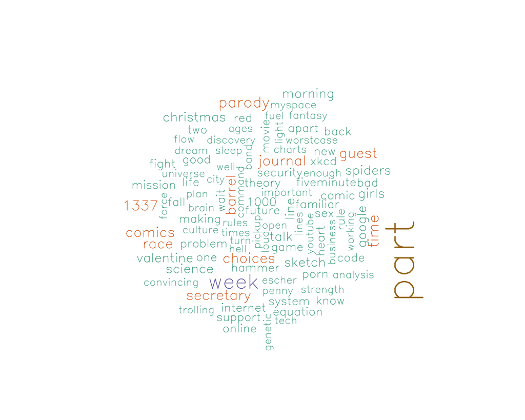

```r
library(tm)
library(wordcloud)
library(RColorBrewer)

# read in our XKCD data
xkcd_df <- read.csv('data/xkcd.csv')

# prepare our data with the tm package
xkcd_corpus <- Corpus(DataframeSource(data.frame(xkcd_df[,'title'])))
xkcd_corpus <- tm_map(xkcd_corpus, removePunctuation)
xkcd_corpus <- tm_map(xkcd_corpus, content_transformer(tolower))
xkcd_corpus <- tm_map(xkcd_corpus, removeWords, stopwords("english"))

# get a matrix of word occurrences
tdm <- TermDocumentMatrix(xkcd_corpus)
m <- as.matrix(tdm)
v <- sort(rowSums(m), decreasing = TRUE)
d <- data.frame(word = names(v), freq = v)
pal <- brewer.pal(7, "Dark2")

# make our wordcloud
wordcloud(
  d$word, d$freq, scale = c(5, 1), min.freq = 2, max.words = 100,
  random.order = T, rot.per = .15, colors = pal,
  vfont = c("sans serif","plain")
)
```

## 1) Your turn

Please answer the following questions. Put all answers and requested figures in a Word document.

1. How many comics are in the data set?
2. What date was the most recent comic in our data set published?
3. What word occurs most frequently in our comic titles? How many times does it occur? (hint: use the `max` and `which` functions; or read about the function `which.max`; or read about `sort`)
4. Modify the code above to make the same type of figure for the data stored in the `transcript` column of `xkcd_df`. Export the figure and include it in your Word document.
5. What word occurs most frequently in the transcripts of the comics and how frequently does it occur? (see hints for part c)

# Homework

## 2) `ggplot2` Tutorial

To reinforce some of the `ggplot2` concepts covered in class and introduce you to some additional ones, please walk through [this `ggplot2` tutorial](http://tutorials.iq.harvard.edu/R/Rgraphics/Rgraphics.html) developed by the Harvard’s [Institute for Quantitative Social Science](http://www.iq.harvard.edu/).

This is a very comprehensive tutorial that will lead you through the process of re-creating a graphic that was published in [The Economist](http://www.economist.com/) – the magazine who told you it [was a good idea to be a math major](http://www.economist.com/blogs/graphicdetail/2015/03/daily-chart-2).

At the end of the tutorial you will have created a complex, publication-ready graphic. **Modify this final graphic in some way – major or minor, it just can’t be the exact same graph you made in the final step. Export this graphic and paste it into your Word document. Write a short paragraph to accompany your final figure. Please detail what you changed and give a brief summary of the graphic you have created.**

## 3) Assigned Reading

Many of the `ggplot2` concepts we covered in class today were taken from the under-development book [`R` for Data Science](http://r4ds.had.co.nz/).

This book is freely available online and is an excellent resource for anyone learning data science or statistics using `R`. Please read through the [Data Vizualization](http://r4ds.had.co.nz/data-visualisation.html) chapter to provide additional context to the topics covered in class. Feel free to try out some of the exercises from the chapter.

Write a paragraph reflecting on the reading and the course to date. Please include the following:

- How you are feeling abou the pace of the class (e.g. “This class is going way to fast” or “I am bored b/c this is easy”)
- How you feel about the course structure – i.e. splitting the class into 1/2 lecture and 1/2 lab
- If having an assingned reading like this is useful to support the class lecture. Do you feel that having a reading or supporting text provides a deeper understanding of the content.